# Stock Returns and Presidential Administrations

Many U.S. presidents have attempted to take credit for the strong performance of the economy or stock market, and political commentators often remark that one party's policies are more favorable for economic growth.

In this exercise, your task is to make a time series plot of the quarterly returns of the S&P 500 stock market index and shade the plot background based on the president's party affiliation: blue for Democrats, red for Republicans.

The file "presidents.csv" contains data on the U.S. presidents since 1950, including their name, the start and end dates of their administration, and their political party affiliation. The file "SP500_daily.csv" contains data on the daily performance of the S&P 500 stock market index since January 3, 1950.

```python
import pandas as pd
import matplotlib.pyplot as plt
```

```python
presidents = pd.read_csv('C:/Users/rudyd/Downloads/presidents.csv', index_col = 'name', parse_dates=['start','end'])
sp500 = pd.read_csv('C:/Users/rudyd/Downloads/SP500_daily.csv', parse_dates = ['Date'])
sp500.columns = map(str.lower, sp500.columns)
sp500 = sp500.set_index('date')
sp500 = sp500.resample('q').mean()
```

```python
sp500['growth rate'] = (sp500['close'].pct_change()*100).fillna(0)
```

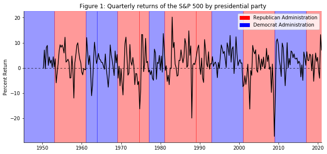

```python
import datetime
import seaborn as sns
from matplotlib.dates import date2num
import matplotlib.patches as mpatches
fig, ax = plt.subplots(figsize = (11,5))
ax.plot(sp500.index, sp500['growth rate'],
       color = 'black',
       label = 'S&P 500 Returns')
ax.set_ylabel('Percent Return')
ax.set_title('Figure 1: Quarterly returns of the S&P 500 by presidential party')

ax.spines['right'].set_visible(False)
ax.spines['top'].set_visible(False)
ax.set_xlim([datetime.date(1945, 4, 12), datetime.date(2021, 1, 12)])
ax.axhline(y=0, color='black', linewidth=0.75, dashes=[5,5])

republican = mpatches.Patch(color='red', label='Republican Administration')
democrat = mpatches.Patch(color='blue', label='Democrat Administration')
plt.legend(handles=[republican,democrat])

for i in range(len(presidents['party'])):
    if presidents['party'][i] == 'Republican':
        ax.axvspan(date2num(presidents['start'][i]), date2num(presidents['end'][i]),
                   color="red", alpha=0.4)
    elif presidents['party'][i] == 'Democrat':
        ax.axvspan(date2num(presidents['start'][i]), date2num(presidents['end'][i]),
                   color="blue", alpha=0.4)
plt.savefig('../SP500.png')
```

# Wages, Education, and Gender

It is well-known that on average, women are paid less than men. However, one might be curious to know whether this depends on educational attainment: is the gender pay gap larger or smaller for people with advanced degrees?

Let's dig into this question. The file "CPS_March_2016.csv" contains the hourly wage, level of education, gender, and full-time work status of a sample of U.S. workers from the Current Population Survey (CPS) from March 2016.

```python
cps_march_2016 = pd.read_csv('C:/Users/rudyd/Downloads/CPS_March_2016.csv', na_values='.')
cps_march_2016 = cps_march_2016[(cps_march_2016['fulltimely'] == 1) & (cps_march_2016['hrwage'] >= 5) & (cps_march_2016['hrwage'] <= 200)]
cps_march_2016['female'] = cps_march_2016['female'].replace({0:'male', 1:'female'})
cps_march_2016.rename(columns = {'female':'gender'}, inplace=True)
obs = len(cps_march_2016.index)
females = cps_march_2016.gender.value_counts()['female']
males = cps_march_2016.gender.value_counts()['male']
print("The total number of observations in the CPS from March 2016 were",obs,"of which",females,"were female and",males,"were male.")
cps_means = pd.DataFrame(cps_march_2016.groupby(['gender'])['hrwage'].mean()).round(2)
avg_female = cps_means['hrwage']['female']
avg_male = cps_means['hrwage']['male']
print("The average hourly wage for females is",avg_female,"dollars and the average hourly wage for males is",avg_male,"dollars.")
```

```
The total number of observations in the CPS from March 2016 were 67771 of which 29995 were female and 37776 were male.
The average hourly wage for females is 22.75 dollars and the average hourly wage for males is 28.31 dollars.
```

1. Compute the average wage for men and the average wage for women with a college degree.
1. Compute the average wage for men and the average wage for women with a graduate degree.
1. Report, in a complete sentence, the ratio of the female avg wage to the male average wage for those with a college degree. Report three decimal places.
1. Report, in a complete sentence, the ratio of the female avg wage to the male average wage for those with a graduate degree. Report three decimal places.
1. Repeat steps 1-4, but computing the standard deviations of the wages.

```python
cps_means_edu = pd.DataFrame(cps_march_2016.groupby(['gender','educ'])['hrwage'].mean()).round(2)
avg_wage = cps_means_edu['hrwage']
avg_male_college = avg_wage['male']['College degree']
avg_female_college = avg_wage['female']['College degree']
avg_male_graduate = avg_wage['male']['Graduate degree']
avg_female_graduate = avg_wage['female']['Graduate degree']
college_ratio = (avg_female_college/avg_male_college).round(3)
graduate_ratio = (avg_female_graduate/avg_male_graduate).round(3)
print("The ratio of female average wage to male average wage for those with a college degree is",college_ratio)
print("The ratio of female average wage to male average wage for those with a graduate degree is",graduate_ratio)
cps_std_edu = pd.DataFrame(cps_march_2016.groupby(['gender','educ'])['hrwage'].std())
std_wage = cps_std_edu['hrwage']
std_male_college = std_wage['male']['College degree']
std_female_college = std_wage['female']['College degree']
std_male_graduate = std_wage['male']['Graduate degree']
std_female_graduate = std_wage['female']['Graduate degree']
std_college_ratio = (std_female_college/std_male_college).round(3)
std_graduate_ratio = (std_female_graduate/std_male_graduate).round(3)
print("The ratio of female standard deviation of wage to male standard deviation of wage for those with a college degree is",std_college_ratio)
print("The ratio of female standard deviation of wage to male standard deviation of wage for those with a graduate degree is",std_graduate_ratio)
```

```
The ratio of female average wage to male average wage for those with a college degree is 0.749
The ratio of female average wage to male average wage for those with a graduate degree is 0.751
The ratio of female standard deviation of wage to male standard deviation of wage for those with a college degree is 0.704
The ratio of female standard deviation of wage to male standard deviation of wage for those with a graduate degree is 0.751
```

```python
cps_means1 = pd.DataFrame(cps_march_2016.groupby(['gender', 'educ'])['hrwage'].mean())
cps_means1 = cps_means1.reset_index()
```

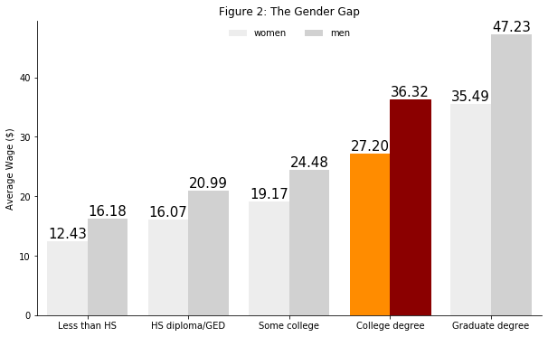

```python
fig, ax = plt.subplots(figsize=(10,6))
my_order = ['Less than HS', 'HS diploma/GED', 'Some college', 'College degree', 'Graduate degree']
sns.barplot(x='educ', y = 'hrwage', hue='gender', data=cps_means1,
           ax = ax, palette = sns.color_palette('Greys'),
           order = my_order)
sns.despine()
ax.set_xlabel('')
ax.set_ylabel('Average Wage ($)')
ax.set_title('Figure 2: The Gender Gap')

ax.legend().set_title('')
handles, labels = ax.get_legend_handles_labels()
ax.legend(handles, ['women', 'men'], frameon=False, ncol=2, loc='upper center')

for p in ax.patches:
    ax.annotate(format(p.get_height(), '.2f'),
                   (p.get_x() + p.get_width() / 2., p.get_height()),
                   ha = 'center', va = 'center',
                   size=15,
                   xytext = (0, 8),
                   textcoords = 'offset points')
for i,v in enumerate(ax.patches):
    if i == 8:
        v.set_color('darkred')
    if i == 3:
        v.set_color('darkorange')
plt.show()
```

# COVID-19 Case Rates

Find data on US COVID-19 case rates on the internet. Hint: The Johns Hopkins Data is pulic-use and available at their github site. You can choose whatever data set you want, though. Part of this question is hunting for data. Make sure your data set is at least a panel with observations by state over time.

```python
covid = pd.read_csv('C:/Users/rudyd/Downloads/us-states.csv', parse_dates = ['date'], index_col = 'date')
covid.sort_values(by = ['state','date'], inplace=True)
covid['7 day rolling avg'] = covid.groupby('state')['cases'].rolling(7).mean().fillna(0).reset_index(0,drop=True)
covid_CA = covid[covid['state']=='California']
covid_NY = covid[covid['state']=='New York']
covid_GA = covid[covid['state']=='Georgia']
covid_FL = covid[covid['state']=='Florida']
covid_TX = covid[covid['state']=='Texas']
```

```
<function matplotlib.pyplot.show(*args, **kw)>
```

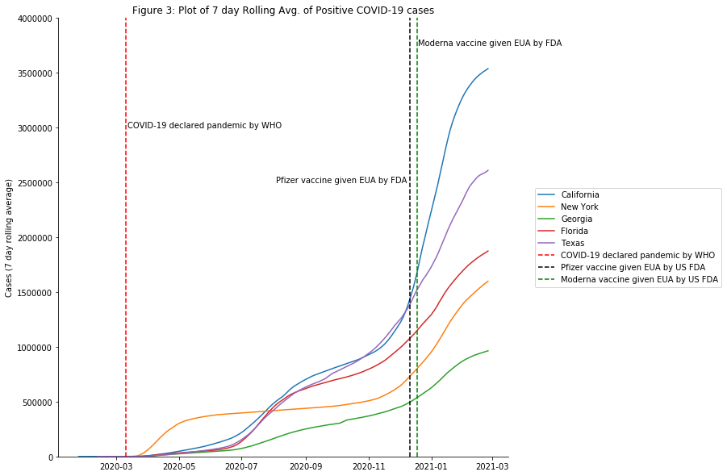

```python
fig, ax = plt.subplots(figsize = (10,10))

ax.plot(covid_CA.index, covid_CA['7 day rolling avg'], label = 'California')
ax.plot(covid_NY.index, covid_NY['7 day rolling avg'], label = 'New York')
ax.plot(covid_GA.index, covid_GA['7 day rolling avg'], label = 'Georgia')
ax.plot(covid_FL.index, covid_FL['7 day rolling avg'], label = 'Florida')
ax.plot(covid_TX.index, covid_TX['7 day rolling avg'], label = 'Texas')

ax.set_ylabel('Cases (7 day rolling average)')
ax.set_title('Figure 3: Plot of 7 day Rolling Avg. of Positive COVID-19 cases')

ax.spines['right'].set_visible(False)
ax.spines['top'].set_visible(False)

ax.axvline("2020-03-11", color="red", linestyle="--", label = 'COVID-19 declared pandemic by WHO')
ax.axvline("2020-12-11", color="black", linestyle="--", label = 'Pfizer vaccine given EUA by US FDA')
ax.axvline("2020-12-18", color="green", linestyle="--", label = 'Moderna vaccine given EUA by US FDA')
ax.text('2020-03-12', 3000000, 'COVID-19 declared pandemic by WHO')
ax.text('2020-08-03', 2500000, 'Pfizer vaccine given EUA by FDA')
ax.text('2020-12-19', 3750000, 'Moderna vaccine given EUA by FDA')
ax.set_ylim([0,4000000])
ax.legend(bbox_to_anchor=(1.05, 0.5), loc="center left")

plt.show
```